# prior_check

### Model goal

Measure the difference between two conditions, for each subject.

The likelihood for the model is always.

$$\begin{aligned}
\mathrm{-likelihood-} \\
error_i &\sim (1-p\_guess_i)*VM(0, \kappa_i) + (p\_guess_i)*Unif(0,2\pi) \\
\\
\mathrm{-param~transformation-} \\
\kappa_i &= sd2k(circ\_sd_i) \\
\end{aligned}$$

The centered parameterization of the linear model would be:

$$\begin{aligned}
\mathrm{-linear~model-} \\
circ\_sd_i &= exp(\alpha_{0,SUBJ[i]} + \alpha_{\Delta,SUBJ[i]} * postCond) ~~ \mathrm{-log~link~on~sd-} \\
p\_guess_i &= inv\_logit(\beta_{0,SUBJ[i]} + \beta_{\Delta,SUBJ[i]} * postCond) ~~ \mathrm{-logit~link~on~p\_guess-} \\
\\
\mathrm{-priors:~all~independent-}\\
\alpha_{0,SUBJ[...]} &\sim Normal(mu\_\alpha_0, sigma\_\alpha_0) \\
\alpha_{\Delta,SUBJ[...]} &\sim Normal(mu\_\alpha_{\Delta}, sigma\_\alpha_{\Delta}) \\
\beta_{0,SUBJ[...]} &\sim Normal(mu\_\beta_0, sigma\_\beta_0) \\
\beta_{\Delta,SUBJ[...]} &\sim Normal(mu\_\beta_{\Delta}, sigma\_\beta_{\Delta}) \\
\\
mu\_\alpha_0 &\sim dist(?)\\
sigma\_\alpha_0 &\sim dist(?) \\
mu\_\alpha_{\Delta} &\sim dist(?)\\
sigma\_\alpha_{\Delta} &\sim dist(?)\\
mu\_\beta_0 &\sim dist(?)\\
sigma\_\beta_0 &\sim dist(?)\\
mu\_\beta_{\Delta} &\sim dist(?)\\
sigma\_\beta_{\Delta} &\sim dist(?)\\
\end{aligned}$$

The actual model I’ll fit, the non-centered parameterization in `brms`, will look more like:

$$\begin{aligned}
\mathrm{-linear~model-} \\
circ\_sd_i &= exp(\alpha_1 + \alpha_{1,SUBJ[i]} + (\alpha_2 + \alpha_{2,SUBJ[i]}) * postCond) ~~ \mathrm{-log~link~on~sd-} \\
p\_guess_i &= inv\_logit(\beta_1 + \beta_{1,SUBJ[i]} + (\beta_2 + \beta_{2,SUBJ[i]}) * postCond) ~~ \mathrm{-logit~link~on~p\_guess-} \\
\\
\mathrm{-priors:~all~independent-}\\
\alpha_{1,SUBJ[...]} &\sim Normal(0, sigma\_\alpha_1) \\
\alpha_{2,SUBJ[...]} &\sim Normal(0, sigma\_\alpha_2) \\
\beta_{1,SUBJ[...]} &\sim Normal(0, sigma\_\beta_1) \\
\beta_{2,SUBJ[...]} &\sim Normal(0, sigma\_\beta_2) \\
\\
\alpha_1 &\sim dist(?)\\
sigma\_\alpha_1 &\sim dist(?) \\
\alpha_2 &\sim dist(?)\\
sigma\_\alpha_2 &\sim dist(?)\\
\beta_1 &\sim dist(?)\\
sigma\_\beta_1 &\sim dist(?)\\
\beta_2 &\sim dist(?)\\
sigma\_\beta_2 &\sim dist(?)\\
\end{aligned}$$

I’ve kept the sigma parameters in the prior notation, when really they should be moved to the linear model and the priors set to $Normal(0,1)$.

The purpose of this document is to figure out reasonable values for those priors, both super uninformative and weakly informative.

##### Priors on slope and intercept with log link

I know that circ_sd should stay between ~20 and ~180. This would be very weakly informative.

```r
library(tidyverse)
library(Rfast)
library(pracma) #rad2deg conversions
```

```r
library(cowplot)
library(sn)
theme_set(theme_cowplot())

my_deg2rad <- function(d){
  #π/180°
  return(d * (pi/180))
}
my_deg2rad_vec <- Vectorize(my_deg2rad)

#helper functions
sd2k <- function(sd_input) {

  #sd_input needs to be radians

  #original matlab code
  # R <- exp(-S.^2/2);
  # K = 1./(R.^3 - 4 * R.^2 + 3 * R);
  # K(R < 0.85) = -0.4 + 1.39 * R(R < 0.85) + 0.43./(1 - R(R < 0.85));
  # K(R < 0.53) = 2 * R(R < 0.53) + R(R < 0.53).^3 + (5 * R(R < 0.53).^5)/6;

  R <- exp(-(sd_input^2)/2)
  K <- 1/((R^3) - (4 * R^2) + (3*R))

  if(R < 0.85){
    K <- -0.4 + (1.39 * R) + (0.43/(1-R))
  }

  if(R < 0.53){
    K <- (2 * R) + R^3 + (5 * R^5)/6
  }


  return(K)
}
sd2k_vec <- Vectorize(sd2k)

#helper functions
sim_vm <- function(k){
  res <- Rfast::rvonmises(1, pi, k, rads = TRUE)
  return(res[1])
}
sim_vm_vec <- Vectorize(sim_vm)
```

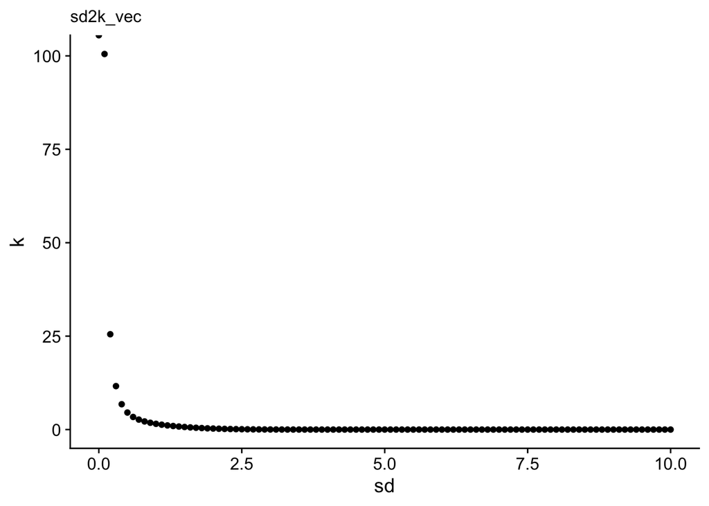

```r
#double check helper func

convert_func <-
  tibble("sd" = seq(0, 10, by = 0.1)) %>%
  mutate("k" = sd2k_vec(sd))

ggplot(convert_func, aes(x = sd, y = k)) +
  geom_point() +
  labs(subtitle = "sd2k_vec")
```

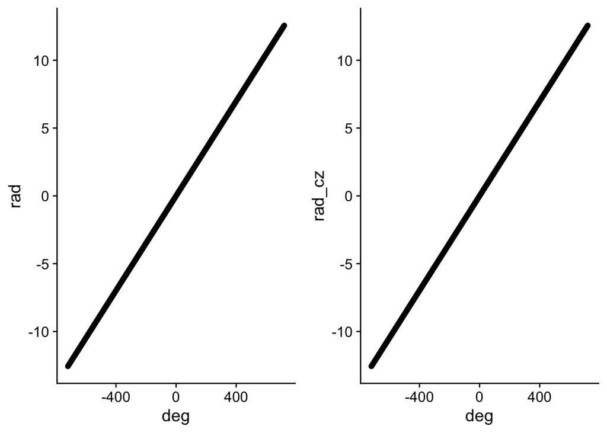

```r
convert_func <-
  tibble("deg" = seq(-720, 720, by = 1)) %>%
  mutate("rad_cz" = my_deg2rad_vec(deg), "rad" = deg2rad(deg))

p1 <- ggplot(convert_func, aes(x = deg, y = rad)) + geom_point()
p2 <- ggplot(convert_func, aes(x = deg, y = rad_cz)) + geom_point()
plot_grid(p1, p2)
```

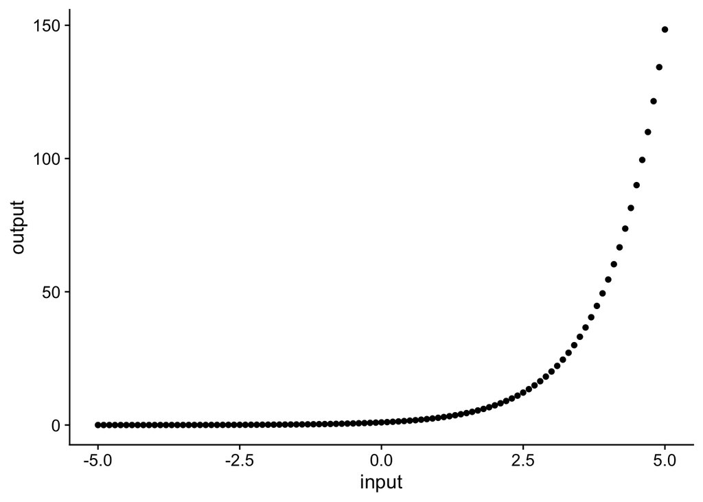

```r
#reminder of how log link transforms values from parameter space

log_link_func <-
  tibble("input" = seq(-5, 5, by = 0.1)) %>%
  mutate("output" = exp(input))

ggplot(log_link_func, aes(x = input, y = output)) +
  geom_point()
```

Placing too much mass below zero in link-space will place loads of mass at zero in de-linked space.

For example a uniform prior $Unif(-5, 5)$ results in a pile of mass on zero.

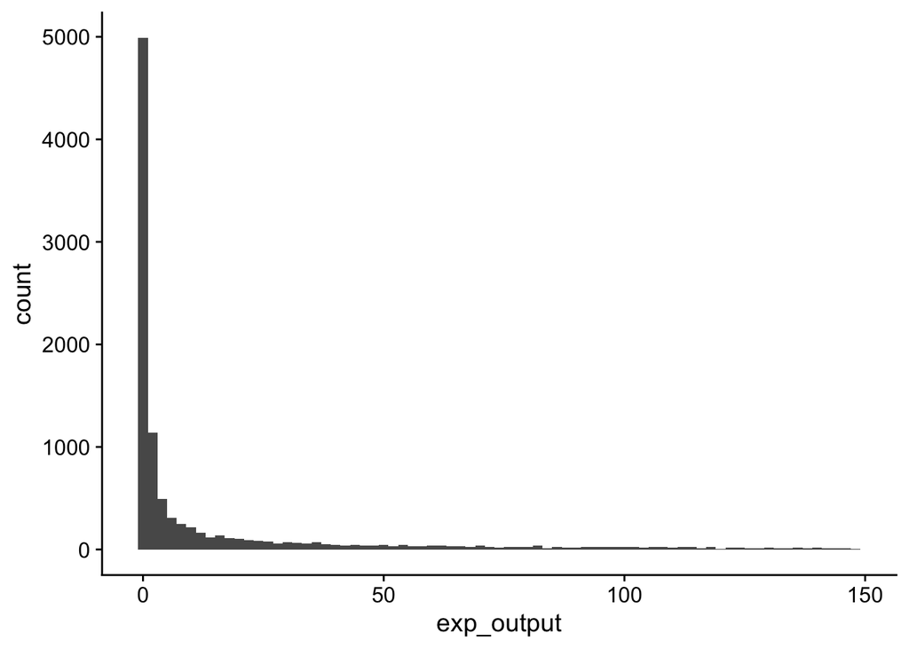

```r
unif_prior_sim <-
  tibble("unif_draws" = runif(1e4, -5, 5)) %>%
  mutate("exp_output" = exp(unif_draws))

ggplot(unif_prior_sim, aes(x = exp_output)) +
  geom_histogram(binwidth = 2)
```

Try a normal prior

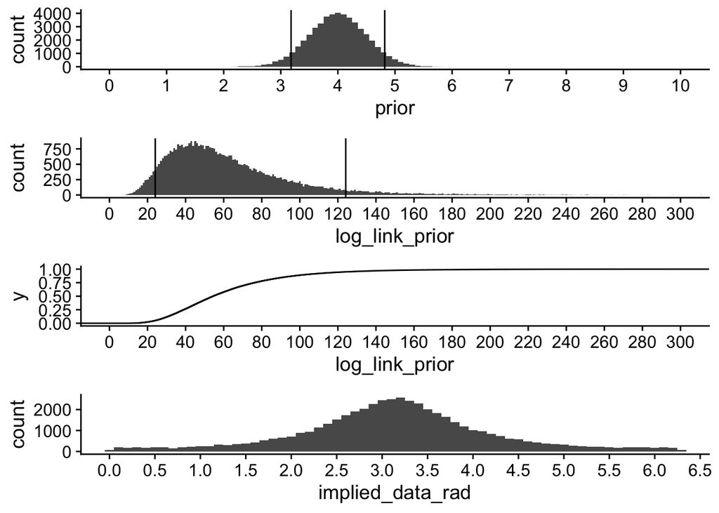

```r
lnorm_prior_sim <-
  tibble("prior" = rnorm(5e4, 4, 0.5)) %>%
  mutate(log_link_prior = exp(prior), log_link_prior_k = sd2k_vec(deg2rad(log_link_prior)), implied_data_rad = map(log_link_prior_k, sim_vm)) %>%
  unnest(implied_data_rad)

hist_quantile <- round(quantile(lnorm_prior_sim$prior, c(0.05, 0.95)), 2)
prior_hist <-
  ggplot(lnorm_prior_sim, aes(x = prior)) +
  geom_histogram(binwidth = 0.1) +
  geom_vline(xintercept = hist_quantile) +
  scale_x_continuous(breaks = scales::pretty_breaks(n = 15)) +
  coord_cartesian(xlim=c(0, 10))

hist_quantile <- round(quantile(lnorm_prior_sim$log_link_prior, c(0.05, 0.95)), 2)
delink_prior_hist <-
  ggplot(lnorm_prior_sim, aes(x = log_link_prior)) +
  geom_histogram(binwidth = 1) +
  geom_vline(xintercept = hist_quantile) +
  scale_x_continuous(breaks = scales::pretty_breaks(n = 15)) +
  coord_cartesian(xlim=c(0, 300))

prior_cdf <-
  ggplot(lnorm_prior_sim, aes(x = log_link_prior)) +
  stat_ecdf() +
  scale_x_continuous(breaks = scales::pretty_breaks(n = 15)) +
  coord_cartesian(xlim=c(0, 300))
  #geom_histogram(binwidth = 1)

data_hist <-
  ggplot(lnorm_prior_sim, aes(x = implied_data_rad)) +
  geom_histogram(binwidth = 0.1) +
  scale_x_continuous(breaks = scales::pretty_breaks(n = 10)) +
  coord_cartesian(xlim=c(0, 2*pi))


plot_grid(prior_hist, delink_prior_hist, prior_cdf, data_hist, ncol = 1, align = "v")
```

Try a skew-normal prior

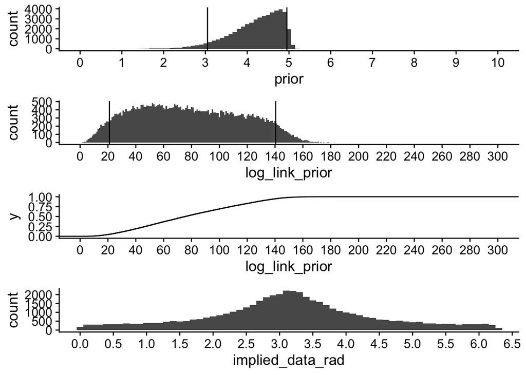

```r
lnorm_prior_sim <-
  tibble("prior" = rsn(5e4, 5, 1, -15)) %>%
  mutate(log_link_prior = exp(prior), log_link_prior_k = sd2k_vec(deg2rad(log_link_prior)), implied_data_rad = map(log_link_prior_k, sim_vm)) %>%
  unnest(implied_data_rad)

hist_quantile <- round(quantile(lnorm_prior_sim$prior, c(0.05, 0.95)), 2)
prior_hist <-
  ggplot(lnorm_prior_sim, aes(x = prior)) +
  geom_histogram(binwidth = 0.1) +
  geom_vline(xintercept = hist_quantile) +
  scale_x_continuous(breaks = scales::pretty_breaks(n = 15)) +
  coord_cartesian(xlim=c(0, 10))

hist_quantile <- round(quantile(lnorm_prior_sim$log_link_prior, c(0.05, 0.95)), 2)
delink_prior_hist <-
  ggplot(lnorm_prior_sim, aes(x = log_link_prior)) +
  geom_histogram(binwidth = 1) +
  geom_vline(xintercept = hist_quantile) +
  scale_x_continuous(breaks = scales::pretty_breaks(n = 15)) +
  coord_cartesian(xlim=c(0, 300))

prior_cdf <-
  ggplot(lnorm_prior_sim, aes(x = log_link_prior)) +
  stat_ecdf() +
  scale_x_continuous(breaks = scales::pretty_breaks(n = 15)) +
  coord_cartesian(xlim=c(0, 300))
  #geom_histogram(binwidth = 1)

data_hist <-
  ggplot(lnorm_prior_sim, aes(x = implied_data_rad)) +
  geom_histogram(binwidth = 0.1) +
  scale_x_continuous(breaks = scales::pretty_breaks(n = 10)) +
  coord_cartesian(xlim=c(0, 2*pi))

plot_grid(prior_hist, delink_prior_hist, prior_cdf, data_hist, ncol = 1, align = "v")
```

Check prior on change in post condition.

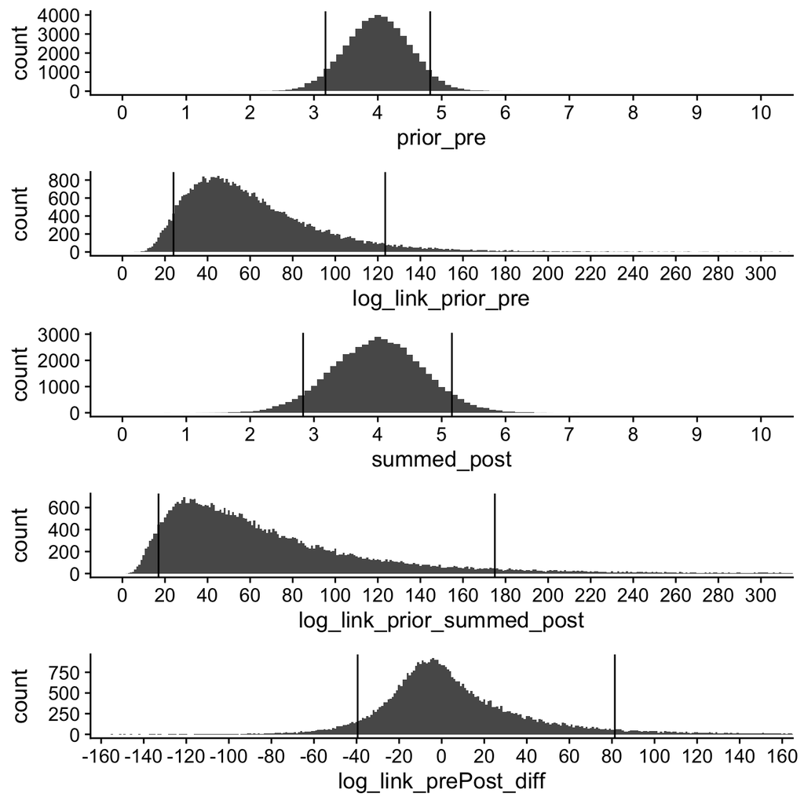

```r
norm_prior_sim <-
  tibble("prior_pre" = rnorm(5e4, 4, 0.5), "prior_post" = rnorm(5e4, 0, 0.5)) %>%
  mutate(summed_post = prior_pre + prior_post) %>%
  mutate(log_link_prior_pre = exp(prior_pre),
         log_link_prior_summed_post = exp(summed_post),
         log_link_prePost_diff = log_link_prior_summed_post - log_link_prior_pre)
  #        log_link_prior_k_pre = sd2k_vec(deg2rad(log_link_prior_pre)),
  #        log_link_prior_k_post = sd2k_vec(deg2rad(log_link_prior_summed_post)),
  #        implied_pre_data_rad = map(log_link_prior_k_pre, sim_vm),
  #        implied_post_data_rad = map(log_link_prior_k_post, sim_vm)) %>%
  # unnest(implied_pre_data_rad, implied_post_data_rad)

#plot prior preCond hist in link space
hist_quantile <- round(quantile(norm_prior_sim$prior_pre, c(0.05, 0.95)), 2)
pre_prior_hist <-
  ggplot(norm_prior_sim, aes(x = prior_pre)) +
  geom_histogram(binwidth = 0.1) +
  geom_vline(xintercept = hist_quantile) +
  scale_x_continuous(breaks = scales::pretty_breaks(n = 15)) +
  coord_cartesian(xlim=c(0, 10))

#plot prior preCond hist in delinked space
hist_quantile <- round(quantile(norm_prior_sim$log_link_prior_pre, c(0.05, 0.95)), 2)
delink_pre_prior_hist <-
  ggplot(norm_prior_sim, aes(x = log_link_prior_pre)) +
  geom_histogram(binwidth = 1) +
  geom_vline(xintercept = hist_quantile) +
  scale_x_continuous(breaks = scales::pretty_breaks(n = 15)) +
  coord_cartesian(xlim=c(0, 300))


#plot prior postCond hist in linked space
hist_quantile <- round(quantile(norm_prior_sim$summed_post, c(0.05, 0.95)), 2)
post_sum_prior_hist <-
  ggplot(norm_prior_sim, aes(x = summed_post)) +
  geom_histogram(binwidth = 0.1) +
  geom_vline(xintercept = hist_quantile) +
  scale_x_continuous(breaks = scales::pretty_breaks(n = 15)) +
  coord_cartesian(xlim=c(0, 10))

#plot prior postCond hist in delinked space
hist_quantile <- round(quantile(norm_prior_sim$log_link_prior_summed_post, c(0.05, 0.95)), 2)
delink_post_sum_prior_hist <-
  ggplot(norm_prior_sim, aes(x = log_link_prior_summed_post)) +
  geom_histogram(binwidth = 1) +
  geom_vline(xintercept = hist_quantile) +
  scale_x_continuous(breaks = scales::pretty_breaks(n = 15)) +
  coord_cartesian(xlim=c(0, 300))



#plot prior postCond-preCond diff in delinked space
hist_quantile <- round(quantile(norm_prior_sim$log_link_prePost_diff, c(0.05, 0.95)), 2)
delinked_prePost_diff_hist <-
  ggplot(norm_prior_sim, aes(x = log_link_prePost_diff)) +
  geom_histogram(binwidth = 1) +
  geom_vline(xintercept = hist_quantile) +
  scale_x_continuous(breaks = scales::pretty_breaks(n = 15)) +
  coord_cartesian(xlim=c(-150, 150))


plot_grid(pre_prior_hist, delink_pre_prior_hist, post_sum_prior_hist, delink_post_sum_prior_hist, delinked_prePost_diff_hist, ncol = 1, align = "v")
```

Notes:

skew-normal is a little unnecessary.

good prior on group mean = Normal(4, 0.5).

good prior on group delta = Normal(0, 0.5). Potentially constrain it to 0.3

Now check prior on p_mem difference

prior(normal(0, 1.5), class = “b”, coef = “intercept”, dpar = “theta”) +

prior(normal(0, 1.5), class = “b”, coef = “stimulation”, dpar = “theta”)

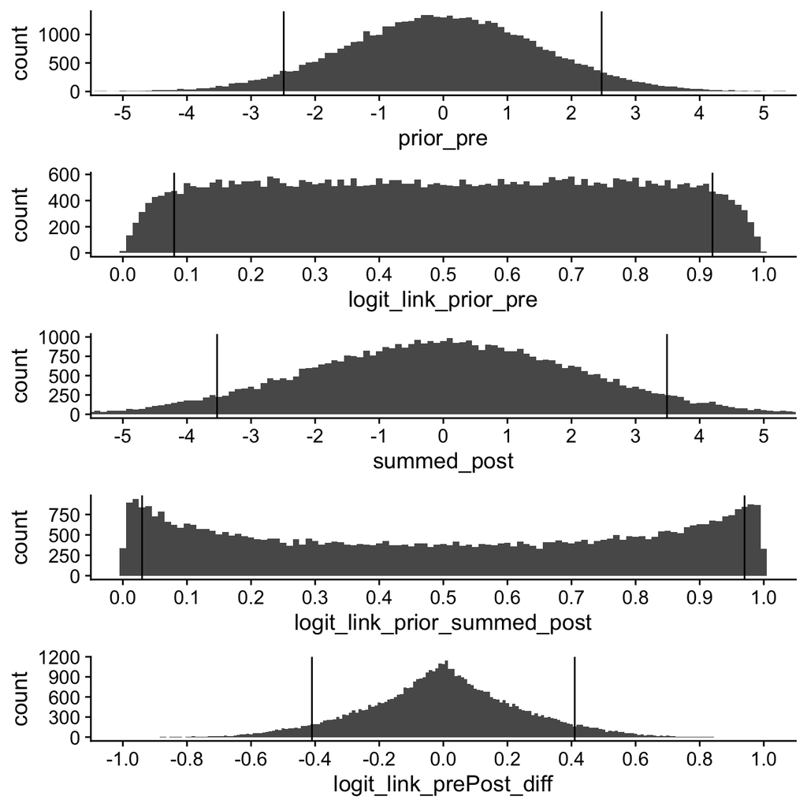

```r
norm_prior_sim <-
  tibble("prior_pre" = rnorm(5e4, 0, 1.5), "prior_post" = rnorm(5e4, 0, 1.5)) %>%
  mutate(summed_post = prior_pre + prior_post) %>%
  mutate(logit_link_prior_pre = exp(prior_pre)/(1 + exp(prior_pre)),
         logit_link_prior_summed_post = exp(summed_post)/(1 + exp(summed_post)),
         logit_link_prePost_diff = logit_link_prior_summed_post - logit_link_prior_pre)
  #        log_link_prior_k_pre = sd2k_vec(deg2rad(log_link_prior_pre)),
  #        log_link_prior_k_post = sd2k_vec(deg2rad(log_link_prior_summed_post)),
  #        implied_pre_data_rad = map(log_link_prior_k_pre, sim_vm),
  #        implied_post_data_rad = map(log_link_prior_k_post, sim_vm)) %>%
  # unnest(implied_pre_data_rad, implied_post_data_rad)

#plot prior preCond hist in link space
hist_quantile <- round(quantile(norm_prior_sim$prior_pre, c(0.05, 0.95)), 2)
pre_prior_hist <-
  ggplot(norm_prior_sim, aes(x = prior_pre)) +
  geom_histogram(binwidth = 0.1) +
  geom_vline(xintercept = hist_quantile) +
  scale_x_continuous(breaks = scales::pretty_breaks(n = 15)) +
  coord_cartesian(xlim=c(-5, 5))

#plot prior preCond hist in delinked space
hist_quantile <- round(quantile(norm_prior_sim$logit_link_prior_pre, c(0.05, 0.95)), 2)
delink_pre_prior_hist <-
  ggplot(norm_prior_sim, aes(x = logit_link_prior_pre)) +
  geom_histogram(binwidth = 0.01) +
  geom_vline(xintercept = hist_quantile) +
  scale_x_continuous(breaks = scales::pretty_breaks(n = 15)) +
  coord_cartesian(xlim=c(0, 1))


#plot prior postCond hist in linked space
hist_quantile <- round(quantile(norm_prior_sim$summed_post, c(0.05, 0.95)), 2)
post_sum_prior_hist <-
  ggplot(norm_prior_sim, aes(x = summed_post)) +
  geom_histogram(binwidth = 0.1) +
  geom_vline(xintercept = hist_quantile) +
  scale_x_continuous(breaks = scales::pretty_breaks(n = 15)) +
  coord_cartesian(xlim=c(-5, 5))

#plot prior postCond hist in delinked space
hist_quantile <- round(quantile(norm_prior_sim$logit_link_prior_summed_post, c(0.05, 0.95)), 2)
delink_post_sum_prior_hist <-
  ggplot(norm_prior_sim, aes(x = logit_link_prior_summed_post)) +
  geom_histogram(binwidth = 0.01) +
  geom_vline(xintercept = hist_quantile) +
  scale_x_continuous(breaks = scales::pretty_breaks(n = 15)) +
  coord_cartesian(xlim=c(0, 1))



#plot prior postCond-preCond diff in delinked space
hist_quantile <- round(quantile(norm_prior_sim$logit_link_prePost_diff, c(0.05, 0.95)), 2)
delinked_prePost_diff_hist <-
  ggplot(norm_prior_sim, aes(x = logit_link_prePost_diff)) +
  geom_histogram(binwidth = 0.01) +
  geom_vline(xintercept = hist_quantile) +
  scale_x_continuous(breaks = scales::pretty_breaks(n = 15)) +
  coord_cartesian(xlim=c(-1, 1))


plot_grid(pre_prior_hist, delink_pre_prior_hist, post_sum_prior_hist, delink_post_sum_prior_hist, delinked_prePost_diff_hist, ncol = 1, align = "v")
```

the prePost difference can only be made more uniform by setting one of the two condition distributions to be highly skewed towards extreme ends.